# Tema 9 Máster en Machine Learning

Ejercicio Obligatorio 1

Illya Bjazevic

2025-09-01

*Datos College*

Analiza la clasificación entre colegios privados y públicos de las universidades de EE. UU. según varios estadísticos de desempeño. Los datos se encuentran en el objeto College del paquete ISLR y corresponden a la edición de 1995 de US News y World Report.

Sigue los siguientes pasos:

1. Observa y grafica los datos.
2. Transforma los datos cuando sea necesario.
3. Divide el conjunto de datos en uno de entrenamiento y otro de prueba.
4. Construye el modelo NN, grafica e interpreta el resultado.
5. Evalúa la performance del modelo NN.

### Parte 1: Observa y grafica los datos.

*En el Paso 1, el código carga los paquetes de trabajo (ggplot2, dplyr, tidyr, forcats, tibble) y el dataset College (priorizando ISLR2 y usando ISLR como respaldo), crea la columna Institution a partir de los nombres de fila si no existe y realiza una inspección inicial de la estructura y primeras filas para detectar tipos de variables y posibles problemas, cumpliendo el objetivo de “observar y graficar los datos” antes del preprocesamiento.*

```r
############################################################
# PASO 1 — OBSERVAR Y GRAFICAR LOS DATOS
# Objetivo: Entender estructura, valores faltantes,
# distribuciones y relaciones clave para guiar el preprocesamiento.
############################################################

# 1) Cargar paquetes (en silencio)
suppressPackageStartupMessages({
  library(ggplot2)   # gráficos
  library(dplyr)     # manipulación de datos
  library(tidyr)     # pivot_longer para histogramas facetados
  library(forcats)   # manejo de factores
  library(tibble)    # rownames_to_column si es necesario
})

# 2) Cargar el dataset College (ISLR2 preferido; ISLR como respaldo)
if (requireNamespace("ISLR2", quietly = TRUE)) {
  data("College", package = "ISLR2")
  df <- ISLR2::College
} else if (requireNamespace("ISLR", quietly = TRUE)) {
  data("College", package = "ISLR")
  df <- ISLR::College
} else {
  stop("Instala ISLR2 o ISLR para acceder al dataset 'College'.")
}

# 3) Asegurar un identificador de institución si viene en los nombres de fila
#    (en ISLR, los nombres de fila suelen ser los nombres de college)
if (!"Institution" %in% names(df)) {
  df <- df %>% rownames_to_column(var = "Institution")
}

# 4) Vista general: estructura, muestra y resumen estadístico
#    (ayuda a detectar tipos de variables y posibles problemas)
str(df)
```

```
## 'data.frame':    777 obs. of  19 variables:
##  $ Institution: chr  "Abilene Christian University" "Adelphi University" "Adrian College" "Agnes Scott College" ...
##  $ Private    : Factor w/ 2 levels "No","Yes": 2 2 2 2 2 2 2 2 2 2 ...
##  $ Apps       : num  1660 2186 1428 417 193 ...
##  $ Accept     : num  1232 1924 1097 349 146 ...
##  $ Enroll     : num  721 512 336 137 55 158 103 489 227 172 ...
##  $ Top10perc  : num  23 16 22 60 16 38 17 37 30 21 ...
##  $ Top25perc  : num  52 29 50 89 44 62 45 68 63 44 ...
##  $ F.Undergrad: num  2885 2683 1036 510 249 ...
##  $ P.Undergrad: num  537 1227 99 63 869 ...
##  $ Outstate   : num  7440 12280 11250 12960 7560 ...
##  $ Room.Board : num  3300 6450 3750 5450 4120 ...
##  $ Books      : num  450 750 400 450 800 500 500 450 300 660 ...
##  $ Personal   : num  2200 1500 1165 875 1500 ...
##  $ PhD        : num  70 29 53 92 76 67 90 89 79 40 ...
##  $ Terminal   : num  78 30 66 97 72 73 93 100 84 41 ...
##  $ S.F.Ratio  : num  18.1 12.2 12.9 7.7 11.9 9.4 11.5 13.7 11.3 11.5 ...
##  $ perc.alumni: num  12 16 30 37 2 11 26 37 23 15 ...
##  $ Expend     : num  7041 10527 8735 19016 10922 ...
##  $ Grad.Rate  : num  60 56 54 59 15 55 63 73 80 52 ...
```

```r
dplyr::glimpse(df)
```

```
## Rows: 777
## Columns: 19
## $ Institution <chr> "Abilene Christian University", "Adelphi University", "Adr…
## $ Private     <fct> Yes, Yes, Yes, Yes, Yes, Yes, Yes, Yes, Yes, Yes, Yes, Yes…
## $ Apps        <dbl> 1660, 2186, 1428, 417, 193, 587, 353, 1899, 1038, 582, 173…
## $ Accept      <dbl> 1232, 1924, 1097, 349, 146, 479, 340, 1720, 839, 498, 1425…
## $ Enroll      <dbl> 721, 512, 336, 137, 55, 158, 103, 489, 227, 172, 472, 484,…
## $ Top10perc   <dbl> 23, 16, 22, 60, 16, 38, 17, 37, 30, 21, 37, 44, 38, 44, 23…
## $ Top25perc   <dbl> 52, 29, 50, 89, 44, 62, 45, 68, 63, 44, 75, 77, 64, 73, 46…
## $ F.Undergrad <dbl> 2885, 2683, 1036, 510, 249, 678, 416, 1594, 973, 799, 1830…
## $ P.Undergrad <dbl> 537, 1227, 99, 63, 869, 41, 230, 32, 306, 78, 110, 44, 638…
## $ Outstate    <dbl> 7440, 12280, 11250, 12960, 7560, 13500, 13290, 13868, 1559…
## $ Room.Board  <dbl> 3300, 6450, 3750, 5450, 4120, 3335, 5720, 4826, 4400, 3380…
## $ Books       <dbl> 450, 750, 400, 450, 800, 500, 500, 450, 300, 660, 500, 400…
## $ Personal    <dbl> 2200, 1500, 1165, 875, 1500, 675, 1500, 850, 500, 1800, 60…
## $ PhD         <dbl> 70, 29, 53, 92, 76, 67, 90, 89, 79, 40, 82, 73, 60, 79, 36…
## $ Terminal    <dbl> 78, 30, 66, 97, 72, 73, 93, 100, 84, 41, 88, 91, 84, 87, 6…
## $ S.F.Ratio   <dbl> 18.1, 12.2, 12.9, 7.7, 11.9, 9.4, 11.5, 13.7, 11.3, 11.5, …
## $ perc.alumni <dbl> 12, 16, 30, 37, 2, 11, 26, 37, 23, 15, 31, 41, 21, 32, 26,…
## $ Expend      <dbl> 7041, 10527, 8735, 19016, 10922, 9727, 8861, 11487, 11644,…
## $ Grad.Rate   <dbl> 60, 56, 54, 59, 15, 55, 63, 73, 80, 52, 73, 76, 74, 68, 55…
```

```r
head(df, 10)
```

```
##                     Institution Private Apps Accept Enroll Top10perc Top25perc
## 1  Abilene Christian University     Yes 1660   1232    721        23        52
## 2            Adelphi University     Yes 2186   1924    512        16        29
## 3                Adrian College     Yes 1428   1097    336        22        50
## 4           Agnes Scott College     Yes  417    349    137        60        89
## 5     Alaska Pacific University     Yes  193    146     55        16        44
## 6             Albertson College     Yes  587    479    158        38        62
## 7       Albertus Magnus College     Yes  353    340    103        17        45
## 8                Albion College     Yes 1899   1720    489        37        68
## 9              Albright College     Yes 1038    839    227        30        63
## 10    Alderson-Broaddus College     Yes  582    498    172        21        44
##    F.Undergrad P.Undergrad Outstate Room.Board Books Personal PhD Terminal
## 1         2885         537     7440       3300   450     2200  70       78
## 2         2683        1227    12280       6450   750     1500  29       30
## 3         1036          99    11250       3750   400     1165  53       66
```

[output cut: 18 more lines]

```r
summary(df)
```

```
##  Institution        Private        Apps           Accept          Enroll
##  Length:777         No :212   Min.   :   81   Min.   :   72   Min.   :  35
##  Class :character   Yes:565   1st Qu.:  776   1st Qu.:  604   1st Qu.: 242
##  Mode  :character             Median : 1558   Median : 1110   Median : 434
##                               Mean   : 3002   Mean   : 2019   Mean   : 780
##                               3rd Qu.: 3624   3rd Qu.: 2424   3rd Qu.: 902
##                               Max.   :48094   Max.   :26330   Max.   :6392
##    Top10perc       Top25perc      F.Undergrad     P.Undergrad
##  Min.   : 1.00   Min.   :  9.0   Min.   :  139   Min.   :    1.0
##  1st Qu.:15.00   1st Qu.: 41.0   1st Qu.:  992   1st Qu.:   95.0
##  Median :23.00   Median : 54.0   Median : 1707   Median :  353.0
##  Mean   :27.56   Mean   : 55.8   Mean   : 3700   Mean   :  855.3
##  3rd Qu.:35.00   3rd Qu.: 69.0   3rd Qu.: 4005   3rd Qu.:  967.0
##  Max.   :96.00   Max.   :100.0   Max.   :31643   Max.   :21836.0
##     Outstate       Room.Board       Books           Personal
##  Min.   : 2340   Min.   :1780   Min.   :  96.0   Min.   : 250
##  1st Qu.: 7320   1st Qu.:3597   1st Qu.: 470.0   1st Qu.: 850
##  Median : 9990   Median :4200   Median : 500.0   Median :1200
##  Mean   :10441   Mean   :4358   Mean   : 549.4   Mean   :1341
##  3rd Qu.:12925   3rd Qu.:5050   3rd Qu.: 600.0   3rd Qu.:1700
##  Max.   :21700   Max.   :8124   Max.   :2340.0   Max.   :6800
##       PhD            Terminal       S.F.Ratio      perc.alumni
##  Min.   :  8.00   Min.   : 24.0   Min.   : 2.50   Min.   : 0.00
##  1st Qu.: 62.00   1st Qu.: 71.0   1st Qu.:11.50   1st Qu.:13.00
##  Median : 75.00   Median : 82.0   Median :13.60   Median :21.00
##  Mean   : 72.66   Mean   : 79.7   Mean   :14.09   Mean   :22.74
##  3rd Qu.: 85.00   3rd Qu.: 92.0   3rd Qu.:16.50   3rd Qu.:31.00
##  Max.   :103.00   Max.   :100.0   Max.   :39.80   Max.   :64.00
##      Expend        Grad.Rate
##  Min.   : 3186   Min.   : 10.00
##  1st Qu.: 6751   1st Qu.: 53.00
##  Median : 8377   Median : 65.00
##  Mean   : 9660   Mean   : 65.46
##  3rd Qu.:10830   3rd Qu.: 78.00
##  Max.   :56233   Max.   :118.00
```

```r
# 5) Calidad de datos: valores faltantes y duplicados
na_counts <- colSums(is.na(df))
na_counts
```

```
## Institution     Private        Apps      Accept      Enroll   Top10perc
##           0           0           0           0           0           0
##   Top25perc F.Undergrad P.Undergrad    Outstate  Room.Board       Books
##           0           0           0           0           0           0
##    Personal         PhD    Terminal   S.F.Ratio perc.alumni      Expend
##           0           0           0           0           0           0
##   Grad.Rate
##           0
```

```r
n_total  <- nrow(df)
n_dupes  <- n_total - nrow(dplyr::distinct(df))
cat("Filas totales:", n_total, " | Duplicados:", n_dupes, "\n")
```

```
## Filas totales: 777  | Duplicados: 0
```

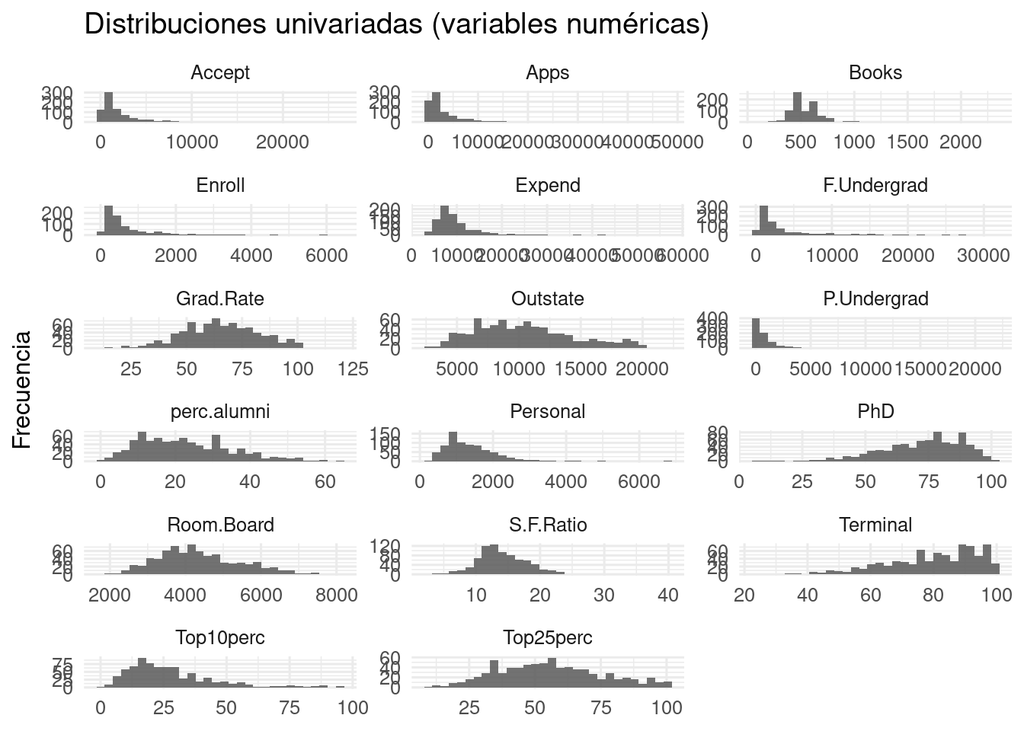

```r
# 6) Asegurar codificación adecuada de la variable objetivo (Privado/Público)
#    En muchos casos viene como "Yes/No"; lo mapeamos a "Private/Public".
df <- df %>%
  mutate(
    Private = if ("Private" %in% names(.)) Private else NA,
    Private = as.factor(Private),
    Private = fct_recode(Private, "Private" = "Yes", "Public" = "No")
  )

# 7) Distribuciones univariadas — variables numéricas (histogramas facetados)
#    Permite revisar escala, sesgo y outliers por variable.
num_vars <- df %>% select(where(is.numeric)) %>% names()

df %>%
  select(all_of(num_vars)) %>%
  pivot_longer(everything(), names_to = "variable", values_to = "valor") %>%
  ggplot(aes(x = valor)) +
  geom_histogram(bins = 30, alpha = 0.85) +
  facet_wrap(~ variable, scales = "free", ncol = 3) +
  labs(title = "Distribuciones univariadas (variables numéricas)",
       x = NULL, y = "Frecuencia") +
  theme_minimal(base_size = 12)
```

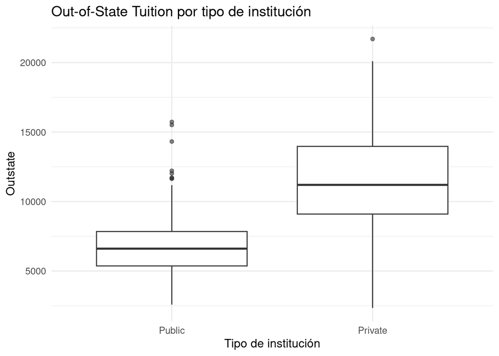

```r
# 8) Boxplots — comparar indicadores clave por tipo de institución (Private)
#    Variables típicas de interés: arancel fuera de estado, gasto y tasa de graduación.
ggplot(df, aes(x = Private, y = Outstate)) +
  geom_boxplot(outlier.alpha = 0.6) +
  labs(title = "Out-of-State Tuition por tipo de institución",
       x = "Tipo de institución", y = "Outstate") +
  theme_minimal(base_size = 12)
```

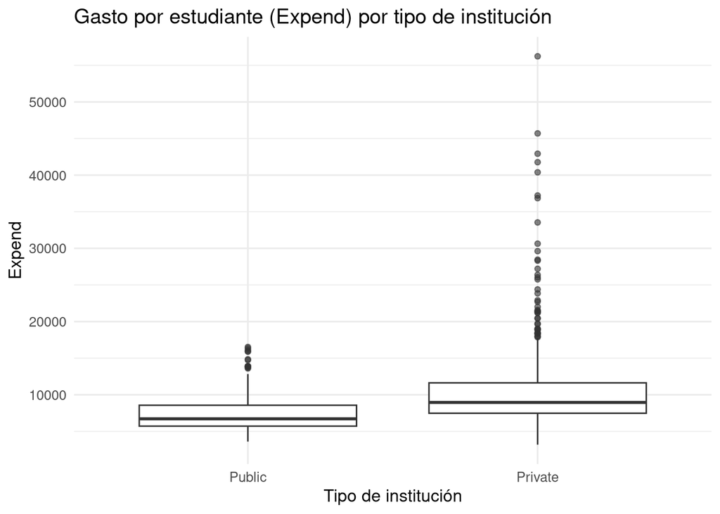

```r
ggplot(df, aes(x = Private, y = Expend)) +
  geom_boxplot(outlier.alpha = 0.6) +
  labs(title = "Gasto por estudiante (Expend) por tipo de institución",
       x = "Tipo de institución", y = "Expend") +
  theme_minimal(base_size = 12)
```

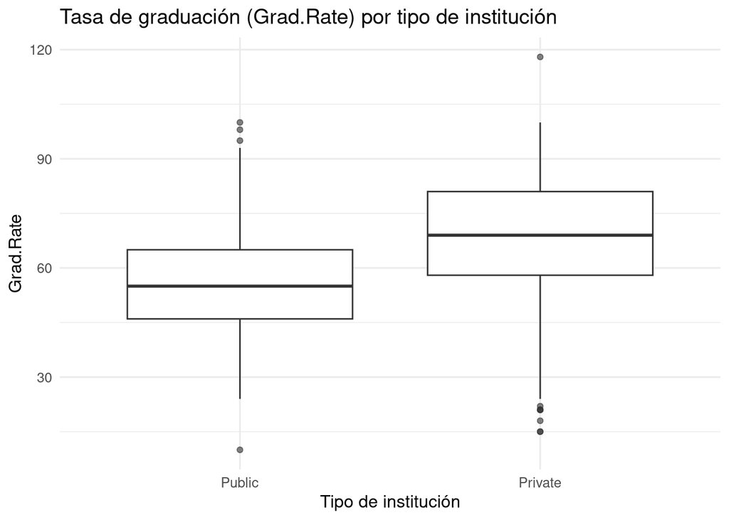

```r
ggplot(df, aes(x = Private, y = `Grad.Rate`)) +
  geom_boxplot(outlier.alpha = 0.6) +
  labs(title = "Tasa de graduación (Grad.Rate) por tipo de institución",
       x = "Tipo de institución", y = "Grad.Rate") +
  theme_minimal(base_size = 12)
```

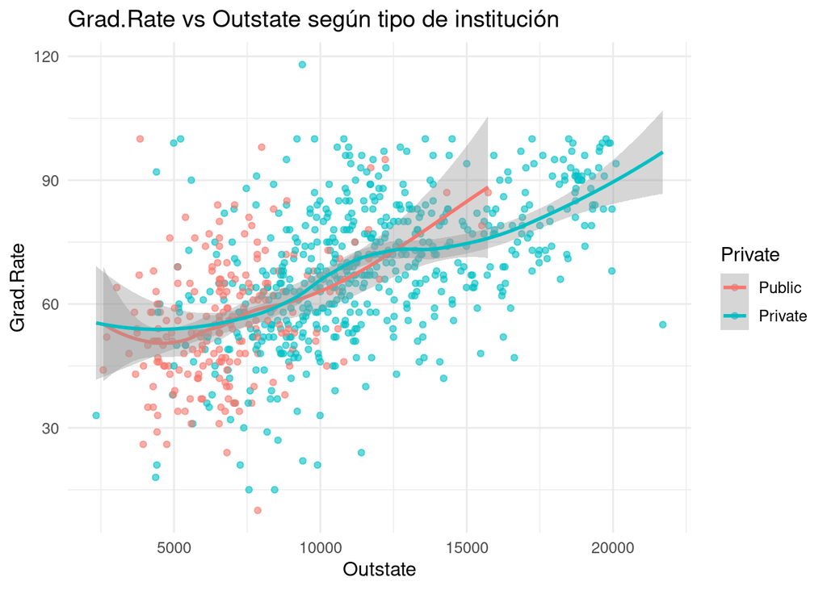

```r
# 9) Relaciones bivariadas clave — dispersión con suavizado
#    Útil para visualizar tendencias y posibles separaciones por Private.
ggplot(df, aes(x = Outstate, y = `Grad.Rate`, color = Private)) +
  geom_point(alpha = 0.6) +
  geom_smooth(method = "loess", se = TRUE) +
  labs(title = "Grad.Rate vs Outstate según tipo de institución",
       x = "Outstate", y = "Grad.Rate") +
  theme_minimal(base_size = 12)
```

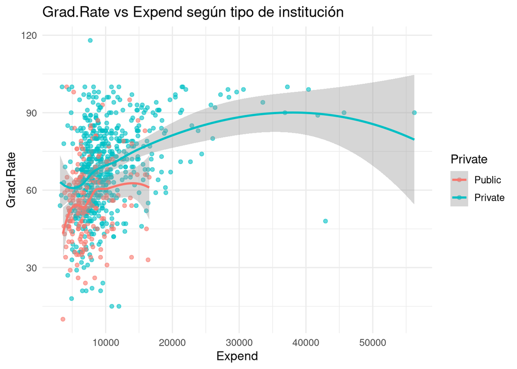

```r
ggplot(df, aes(x = Expend, y = `Grad.Rate`, color = Private)) +
  geom_point(alpha = 0.6) +
  geom_smooth(method = "loess", se = TRUE) +
  labs(title = "Grad.Rate vs Expend según tipo de institución",
       x = "Expend", y = "Grad.Rate") +
  theme_minimal(base_size = 12)
```

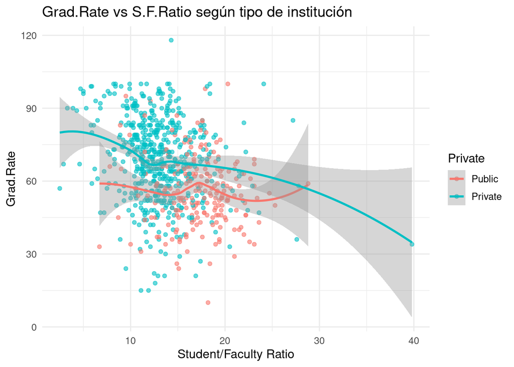

```r
ggplot(df, aes(x = `S.F.Ratio`, y = `Grad.Rate`, color = Private)) +
  geom_point(alpha = 0.6) +
  geom_smooth(method = "loess", se = TRUE) +
  labs(title = "Grad.Rate vs S.F.Ratio según tipo de institución",
       x = "Student/Faculty Ratio", y = "Grad.Rate") +
  theme_minimal(base_size = 12)
```

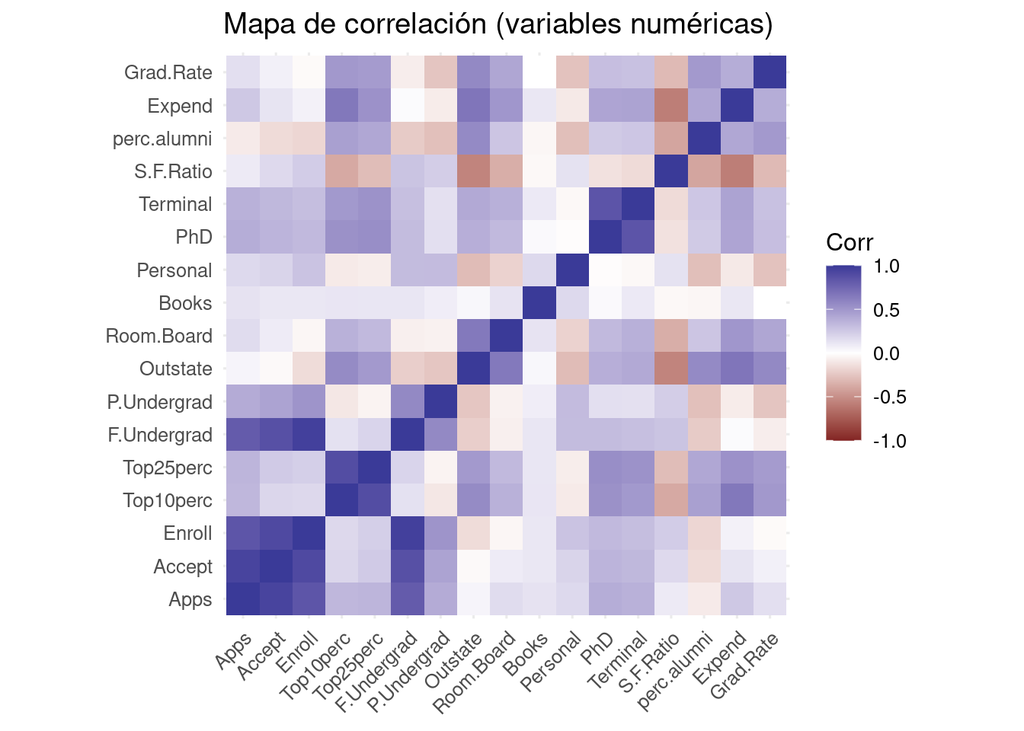

```r
# 10) Mapa de correlación — solo variables numéricas
#     pairwise.complete.obs evita problemas si hay NAs en alguna columna.
cor_mat  <- cor(df %>% select(where(is.numeric)), use = "pairwise.complete.obs")
cor_long <- as.data.frame(as.table(cor_mat))
colnames(cor_long) <- c("Var1", "Var2", "Corr")

ggplot(cor_long, aes(Var1, Var2, fill = Corr)) +
  geom_tile() +
  scale_fill_gradient2(limits = c(-1, 1)) +
  coord_fixed() +
  labs(title = "Mapa de correlación (variables numéricas)",
       x = NULL, y = NULL) +
  theme_minimal(base_size = 12) +
  theme(axis.text.x = element_text(angle = 45, hjust = 1))
```

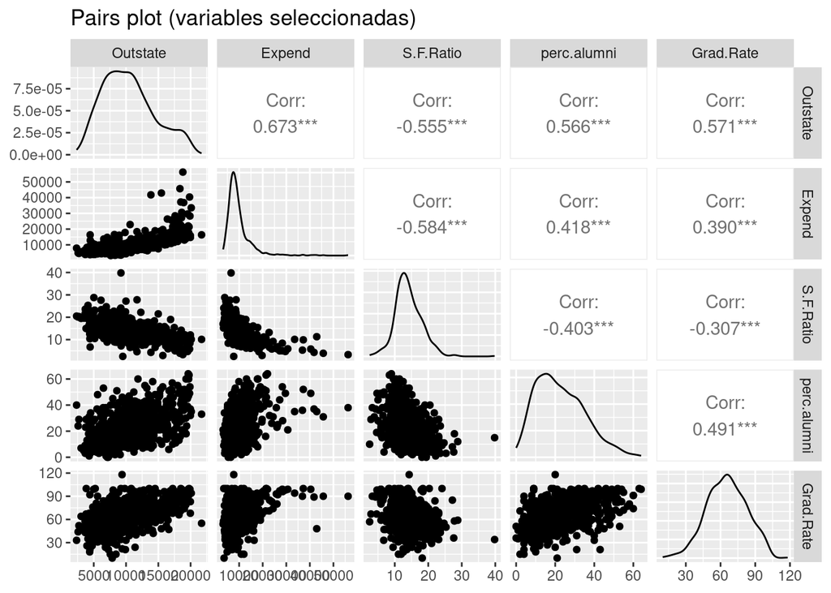

```r
# 11) Opcional: pairs plot rápido si está GGally disponible (vista global)
if (requireNamespace("GGally", quietly = TRUE)) {
  suppressPackageStartupMessages(library(GGally))
  df %>%
    select(Outstate, Expend, `S.F.Ratio`, perc.alumni, `Grad.Rate`) %>%
    GGally::ggpairs(title = "Pairs plot (variables seleccionadas)")
}
```

### Parte 2: Transforma los datos cuando sea necesario.

*En el Paso 2, el código verifica que el conjunto de datos esté cargado, conserva Institution solo como identificador y crea una versión para modelado sin esa columna, estandariza la variable objetivo Private como factor binario coherente (“Public”/“Private”), corrige el valor imposible de Grad.Rate capándolo en 100, comprueba la ausencia de NA, y entrega dos data frames listos para continuar: college_transformado (con Institution) y college_para_modelo (sin Institution).*

```r
# =========================
# PASO 2 — Transformaciones necesarias (SIN repetir el PASO 1)
# Precondición: existe 'df' en memoria, ya con columna 'Institution'
# =========================


# 1) Asegurar la variable objetivo como factor legible: 'Private' (Public/Private)
if (!"Private" %in% names(df)) stop("No se encontró la columna 'Private'.")
# Reetiquetar si viene como Yes/No
if (is.factor(df$Private)) {
  # Intentar mapear niveles comunes "No/Yes" -> "Public/Private"
  lev <- levels(df$Private)
  if (all(c("No","Yes") %in% lev)) {
    df$Private <- factor(df$Private,
                         levels = c("No","Yes"),
                         labels = c("Public","Private"))
  }
} else {
  # Si no es factor, forzar a factor (esperando valores "No/Yes" o 0/1)
  df$Private <- factor(df$Private, levels = c("No","Yes"),
                       labels = c("Public","Private"))
}

# 2) Corregir valor fuera de rango en 'Grad.Rate' (capar a 100)
if (!"Grad.Rate" %in% names(df)) stop("No se encontró la columna 'Grad.Rate'.")
idx_gt_100 <- which(df$Grad.Rate > 100)
if (length(idx_gt_100) > 0) df$Grad.Rate[idx_gt_100] <- 100

# 3) Chequeo rápido de valores perdidos
na_por_col <- colSums(is.na(df))
if (any(na_por_col > 0)) {
  stop("Hay NA inesperados tras la limpieza. Revisa 'na_por_col'.")
}

# 4) Versiones de salida
#    - 'college_transformado': conserva 'Institution' (para reportes/joins)
#    - 'college_para_modelo' : elimina 'Institution' (lista para modelar)
college_transformado <- df
college_para_modelo  <- df[ , setdiff(names(df), "Institution")]

# 5) Mensajes de control (puedes comentar si no quieres imprimir)
cat("Filas ajustadas en Grad.Rate (>100):", length(idx_gt_100), "\n")
```

```
## Filas ajustadas en Grad.Rate (>100): 1
```

```r
cat("Dimensiones (con Institution): ", paste(dim(college_transformado), collapse = " x "), "\n")
```

```
## Dimensiones (con Institution):  777 x 19
```

```r
cat("Dimensiones (para modelar)   : ", paste(dim(college_para_modelo),  collapse = " x "), "\n")
```

```
## Dimensiones (para modelar)   :  777 x 18
```

```r
# 4) Vista general: estructura, muestra y resumen estadístico
#    (ayuda a detectar tipos de variables y posibles problemas)
str(college_para_modelo)
```

```
## 'data.frame':    777 obs. of  18 variables:
##  $ Private    : Factor w/ 2 levels "Public","Private": 2 2 2 2 2 2 2 2 2 2 ...
##  $ Apps       : num  1660 2186 1428 417 193 ...
##  $ Accept     : num  1232 1924 1097 349 146 ...
##  $ Enroll     : num  721 512 336 137 55 158 103 489 227 172 ...
##  $ Top10perc  : num  23 16 22 60 16 38 17 37 30 21 ...
##  $ Top25perc  : num  52 29 50 89 44 62 45 68 63 44 ...
##  $ F.Undergrad: num  2885 2683 1036 510 249 ...
##  $ P.Undergrad: num  537 1227 99 63 869 ...
##  $ Outstate   : num  7440 12280 11250 12960 7560 ...
##  $ Room.Board : num  3300 6450 3750 5450 4120 ...
##  $ Books      : num  450 750 400 450 800 500 500 450 300 660 ...
##  $ Personal   : num  2200 1500 1165 875 1500 ...
##  $ PhD        : num  70 29 53 92 76 67 90 89 79 40 ...
##  $ Terminal   : num  78 30 66 97 72 73 93 100 84 41 ...
##  $ S.F.Ratio  : num  18.1 12.2 12.9 7.7 11.9 9.4 11.5 13.7 11.3 11.5 ...
##  $ perc.alumni: num  12 16 30 37 2 11 26 37 23 15 ...
##  $ Expend     : num  7041 10527 8735 19016 10922 ...
##  $ Grad.Rate  : num  60 56 54 59 15 55 63 73 80 52 ...
```

```r
dplyr::glimpse(college_para_modelo)
```

```
## Rows: 777
## Columns: 18
## $ Private     <fct> Private, Private, Private, Private, Private, Private, Priv…
## $ Apps        <dbl> 1660, 2186, 1428, 417, 193, 587, 353, 1899, 1038, 582, 173…
## $ Accept      <dbl> 1232, 1924, 1097, 349, 146, 479, 340, 1720, 839, 498, 1425…
## $ Enroll      <dbl> 721, 512, 336, 137, 55, 158, 103, 489, 227, 172, 472, 484,…
## $ Top10perc   <dbl> 23, 16, 22, 60, 16, 38, 17, 37, 30, 21, 37, 44, 38, 44, 23…
## $ Top25perc   <dbl> 52, 29, 50, 89, 44, 62, 45, 68, 63, 44, 75, 77, 64, 73, 46…
## $ F.Undergrad <dbl> 2885, 2683, 1036, 510, 249, 678, 416, 1594, 973, 799, 1830…
## $ P.Undergrad <dbl> 537, 1227, 99, 63, 869, 41, 230, 32, 306, 78, 110, 44, 638…
## $ Outstate    <dbl> 7440, 12280, 11250, 12960, 7560, 13500, 13290, 13868, 1559…
## $ Room.Board  <dbl> 3300, 6450, 3750, 5450, 4120, 3335, 5720, 4826, 4400, 3380…
## $ Books       <dbl> 450, 750, 400, 450, 800, 500, 500, 450, 300, 660, 500, 400…
## $ Personal    <dbl> 2200, 1500, 1165, 875, 1500, 675, 1500, 850, 500, 1800, 60…
## $ PhD         <dbl> 70, 29, 53, 92, 76, 67, 90, 89, 79, 40, 82, 73, 60, 79, 36…
## $ Terminal    <dbl> 78, 30, 66, 97, 72, 73, 93, 100, 84, 41, 88, 91, 84, 87, 6…
## $ S.F.Ratio   <dbl> 18.1, 12.2, 12.9, 7.7, 11.9, 9.4, 11.5, 13.7, 11.3, 11.5, …
## $ perc.alumni <dbl> 12, 16, 30, 37, 2, 11, 26, 37, 23, 15, 31, 41, 21, 32, 26,…
## $ Expend      <dbl> 7041, 10527, 8735, 19016, 10922, 9727, 8861, 11487, 11644,…
## $ Grad.Rate   <dbl> 60, 56, 54, 59, 15, 55, 63, 73, 80, 52, 73, 76, 74, 68, 55…
```

```r
head(college_para_modelo, 10)
```

```
##    Private Apps Accept Enroll Top10perc Top25perc F.Undergrad P.Undergrad
## 1  Private 1660   1232    721        23        52        2885         537
## 2  Private 2186   1924    512        16        29        2683        1227
## 3  Private 1428   1097    336        22        50        1036          99
## 4  Private  417    349    137        60        89         510          63
## 5  Private  193    146     55        16        44         249         869
## 6  Private  587    479    158        38        62         678          41
## 7  Private  353    340    103        17        45         416         230
## 8  Private 1899   1720    489        37        68        1594          32
## 9  Private 1038    839    227        30        63         973         306
## 10 Private  582    498    172        21        44         799          78
##    Outstate Room.Board Books Personal PhD Terminal S.F.Ratio perc.alumni Expend
## 1      7440       3300   450     2200  70       78      18.1          12   7041
## 2     12280       6450   750     1500  29       30      12.2          16  10527
## 3     11250       3750   400     1165  53       66      12.9          30   8735
```

[output cut: 18 more lines]

```r
summary(college_para_modelo)
```

```
##     Private         Apps           Accept          Enroll       Top10perc
##  Public :212   Min.   :   81   Min.   :   72   Min.   :  35   Min.   : 1.00
##  Private:565   1st Qu.:  776   1st Qu.:  604   1st Qu.: 242   1st Qu.:15.00
##                Median : 1558   Median : 1110   Median : 434   Median :23.00
##                Mean   : 3002   Mean   : 2019   Mean   : 780   Mean   :27.56
##                3rd Qu.: 3624   3rd Qu.: 2424   3rd Qu.: 902   3rd Qu.:35.00
##                Max.   :48094   Max.   :26330   Max.   :6392   Max.   :96.00
##    Top25perc      F.Undergrad     P.Undergrad         Outstate
##  Min.   :  9.0   Min.   :  139   Min.   :    1.0   Min.   : 2340
##  1st Qu.: 41.0   1st Qu.:  992   1st Qu.:   95.0   1st Qu.: 7320
##  Median : 54.0   Median : 1707   Median :  353.0   Median : 9990
##  Mean   : 55.8   Mean   : 3700   Mean   :  855.3   Mean   :10441
##  3rd Qu.: 69.0   3rd Qu.: 4005   3rd Qu.:  967.0   3rd Qu.:12925
##  Max.   :100.0   Max.   :31643   Max.   :21836.0   Max.   :21700
##    Room.Board       Books           Personal         PhD
##  Min.   :1780   Min.   :  96.0   Min.   : 250   Min.   :  8.00
##  1st Qu.:3597   1st Qu.: 470.0   1st Qu.: 850   1st Qu.: 62.00
##  Median :4200   Median : 500.0   Median :1200   Median : 75.00
##  Mean   :4358   Mean   : 549.4   Mean   :1341   Mean   : 72.66
##  3rd Qu.:5050   3rd Qu.: 600.0   3rd Qu.:1700   3rd Qu.: 85.00
##  Max.   :8124   Max.   :2340.0   Max.   :6800   Max.   :103.00
##     Terminal       S.F.Ratio      perc.alumni        Expend
##  Min.   : 24.0   Min.   : 2.50   Min.   : 0.00   Min.   : 3186
##  1st Qu.: 71.0   1st Qu.:11.50   1st Qu.:13.00   1st Qu.: 6751
##  Median : 82.0   Median :13.60   Median :21.00   Median : 8377
##  Mean   : 79.7   Mean   :14.09   Mean   :22.74   Mean   : 9660
##  3rd Qu.: 92.0   3rd Qu.:16.50   3rd Qu.:31.00   3rd Qu.:10830
##  Max.   :100.0   Max.   :39.80   Max.   :64.00   Max.   :56233
##    Grad.Rate
##  Min.   : 10.00
##  1st Qu.: 53.00
##  Median : 65.00
##  Mean   : 65.44
##  3rd Qu.: 78.00
##  Max.   :100.00
```